# Berlin CO2 Leistungsbild

## 3.2. Flächenbezug

### 3.2.1. Berlin, Mehrfamiliengebäude, flächenbezogene CO2-Emission aus der Beheizung von Wohnraum 2002 - 2018 in kg/m2[AN]

```r
bezirk_areas_mfh$abrechnungsjahr <- 2002:2018
bezirk_areas_mfh
```

```
##    abrechnungsjahr charlottenburg_wilmersdorf friedrichshain_kreuzberg
## 1             2002                   12306348                  8888746
## 2             2003                   12359000                  8967575
## 3             2004                   12411652                  9046404
## 4             2005                   12464305                  9125232
## 5             2006                   12516957                  9204061
## 6             2007                   12569610                  9282889
## 7             2008                   12622262                  9361718
## 8             2009                   12674914                  9440546
## 9             2010                   12756700                  9586900
## 10            2011                   12788900                  9617800
## 11            2012                   12819500                  9641900
## 12            2013                   12856100                  9691100
## 13            2014                   12924500                  9772300
## 14            2015                   12973400                  9924900
```

[output cut: 57 more lines]

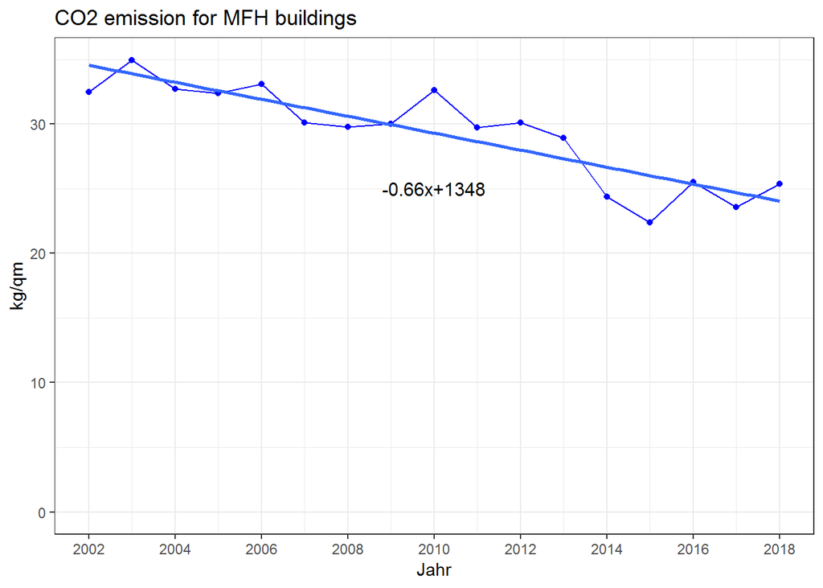

```r
spz_co2_mfh <- 1e6*berlin_co2_mfh$total/bezirk_areas_mfh$total
spez_co2_mfh <- data.frame(abrechnungsjahr=2002:2018 , spez_co2 = spz_co2_mfh )

points_line_lm(input_data = spez_co2_mfh,
               xVar = "abrechnungsjahr",
               yVar = "spez_co2",
               ymin=0,
               ymax=max(spez_co2_mfh$spez_co2),
               x_eq = 2010,
               y_eq = 25,
               size_eq = 4,
               plot_title = "CO2 emission for MFH buildings",
               xlab = "Jahr",
               ylab = "kg/qm")
```

```r
i_subsubsection <- i_subsubsection + 1
```

```r
bezirke_spez_co2_mfh <- 1e6*berlin_co2_mfh/bezirk_areas_mfh
bezirke_spez_co2_mfh$abrechnungsjahr <- 2002:2018
```

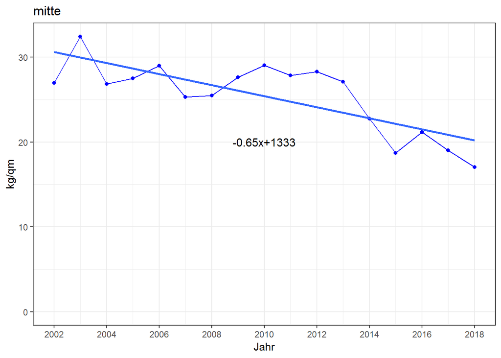

```r
bindex <- 5
points_line_lm(input_data = bezirke_spez_co2_mfh,
               xVar = "abrechnungsjahr",
               yVar = bezirk_list[bindex],
               ymin=0,
               ymax=max(bezirke_spez_co2_mfh[[bezirk_list[bindex]]]),
               x_eq = 2010,
               y_eq = 20,
               size_eq = 4,
               plot_title = bezirk_list[bindex],
               xlab = "Jahr",
               ylab = "kg/qm")
```

```r
i_subsubsection <- i_subsubsection + 1
```

### 3.2.3. Stadtbezirke, Mehrfamiliengebäude, flächenbezogene CO2-Emission aus der Beheizung von Wohnraum im Jahr 2018 in kg/m2[AN]

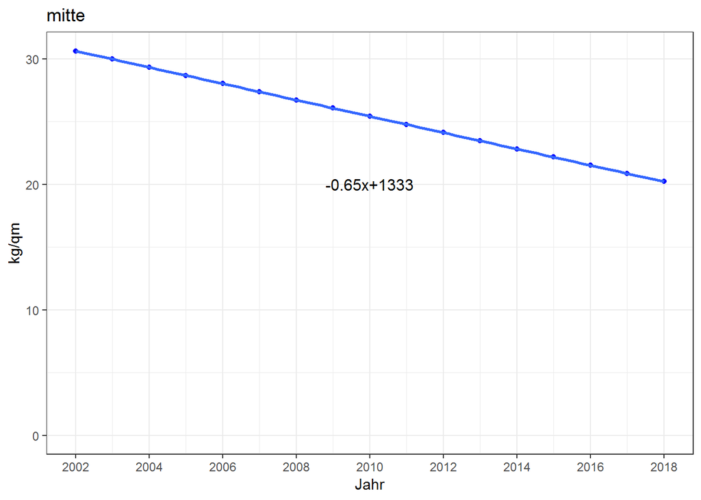

```r
bezirke_spez_co2_mfh_linear <- linearizer(bezirke_spez_co2_mfh , dropCols = NULL , xVar = "abrechnungsjahr")
bindex <- 5
points_line_lm(input_data = bezirke_spez_co2_mfh_linear,
               xVar = "abrechnungsjahr",
               yVar = bezirk_list[bindex],
               ymin=0,
               ymax=max(bezirke_spez_co2_mfh_linear[[bezirk_list[bindex]]]),
               x_eq = 2010,
               y_eq = 20,
               size_eq = 4,
               plot_title = bezirk_list[bindex],
               xlab = "Jahr",
               ylab = "kg/qm")
```

```r
bezirke_spez_co2_mfh_linear_2018 <- bezirke_spez_co2_mfh_linear[bezirke_spez_co2_mfh_linear$abrechnungsjahr==2018 , ]
bezirke_spezco2_mfh_linear_2018 <- as.data.frame(t(bezirke_spez_co2_mfh_linear_2018))
bezirke_spezco2_mfh_linear_2018$bezirk <- row.names(bezirke_spezco2_mfh_linear_2018)
names(bezirke_spezco2_mfh_linear_2018) <- c("wert","bezirk")
bezirke_spezco2_mfh_linear_2018 <- bezirke_spezco2_mfh_linear_2018[bezirke_spezco2_mfh_linear_2018$bezirk!="abrechnungsjahr" , ]
bezirke_spezco2_mfh_linear_2018 <- bezirke_spezco2_mfh_linear_2018[bezirke_spezco2_mfh_linear_2018$bezirk!="total" , ]
bezirke_spezco2_mfh_linear_2018
```

```
##                                wert                     bezirk
## charlottenburg_wilmersdorf 23.71006 charlottenburg_wilmersdorf
## friedrichshain_kreuzberg   20.37490   friedrichshain_kreuzberg
## lichtenberg                19.44274                lichtenberg
## marzahn_hellersdorf        28.22129        marzahn_hellersdorf
## mitte                      20.21140                      mitte
## neukoelln                  22.91205                  neukoelln
## pankow                     20.04699                     pankow
## reinickendorf              33.30245              reinickendorf
## spandau                    30.00880                    spandau
## steglitz_zehlendorf        31.95092        steglitz_zehlendorf
## tempelhof_schoeneberg      25.22699      tempelhof_schoeneberg
## treptow_koepenick          21.49346          treptow_koepenick
```

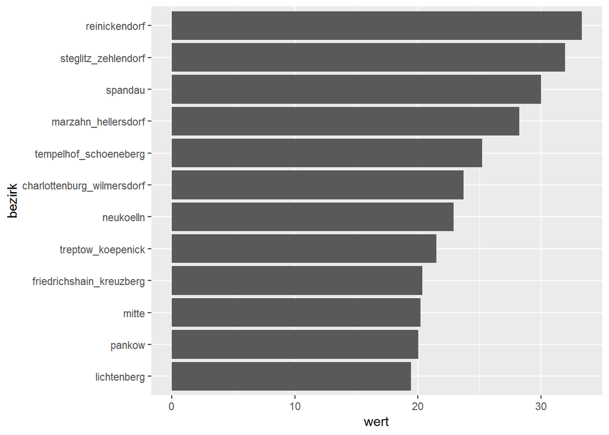

```r
bezirke_spezco2_mfh_linear_2018$bezirk <- factor(
      bezirke_spezco2_mfh_linear_2018$bezirk ,
      levels = bezirke_spezco2_mfh_linear_2018$bezirk[order(bezirke_spezco2_mfh_linear_2018$wert)])
#barplot(bezirke_spezco2_linear_2018$wert)
ggplot(data=bezirke_spezco2_mfh_linear_2018,aes(x=bezirk,y=wert))+geom_bar(stat="identity")+coord_flip()
```

```r
i_subsubsection <- i_subsubsection + 1
```

```r
get2002as100(spez_co2_mfh , "abrechnungsjahr")
```

```
##    abrechnungsjahr  spez_co2
## 1             2002 100.00000
## 2             2003 107.63571
## 3             2004 100.65766
## 4             2005  99.74783
## 5             2006 101.91587
## 6             2007  92.62924
## 7             2008  91.66728
## 8             2009  92.38264
## 9             2010 100.49165
## 10            2011  91.46458
## 11            2012  92.73462
## 12            2013  89.09921
## 13            2014  75.09067
## 14            2015  68.94733
## 15            2016  78.54783
## 16            2017  72.59875
## 17            2018  78.05759
```

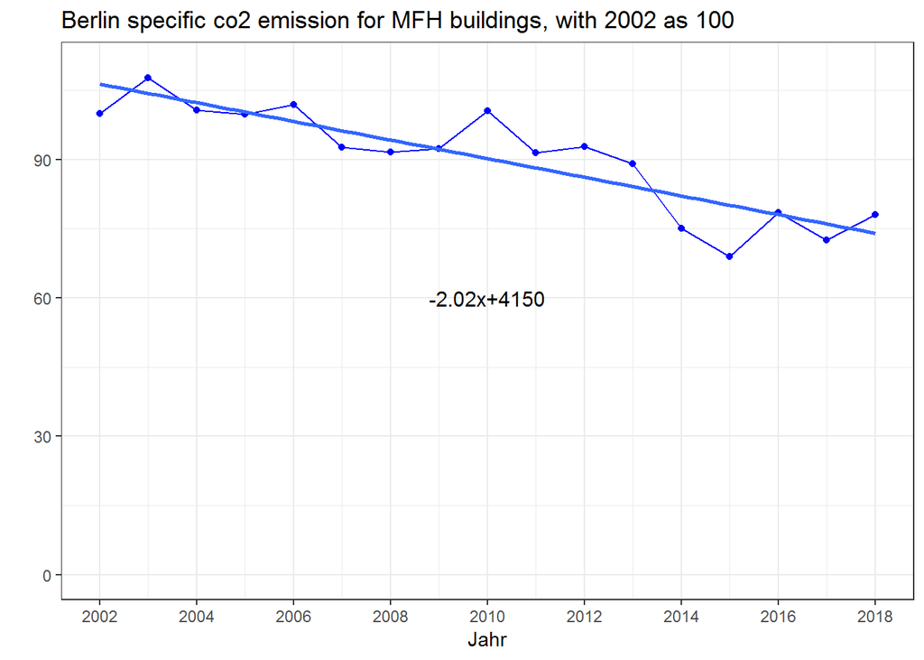

```r
points_line_lm(input_data = get2002as100(spez_co2_mfh , "abrechnungsjahr"),
               xVar = "abrechnungsjahr",
               yVar = "spez_co2",
               ymin=0,
               ymax=110,
               x_eq = 2010,
               y_eq = 60,
               size_eq = 4,
               plot_title = "Berlin specific co2 emission for MFH buildings, with 2002 as 100",
               xlab = "Jahr",
               ylab = " ")
```

```r
i_subsubsection <- i_subsubsection + 1
```

### 3.2.5. Alle Stadtbezirke, Mehrfamiliengebäude, flächenbezogene CO2-Emission aus der Beheizung von Wohnraum, Entwicklung 2002 - 2018 und Niveau 2018 (Rang¬folge)

```r
i_subsubsection <- i_subsubsection + 1
```

### 3.2.6. Berlin, Mehrfamiliengebäude, durchschnittliche Emissionsminderung je qm Nutzfläche im Zeitraum 2012 - 2018

```r
i_subsection <- i_subsection + 1
i_subsubsection <- 1
```

## 3.3. Emission pro Einwohner

### 3.3.1. Stadtbezirke, Mehrfamiliengebäude, CO2-Emission aus der Beheizung von Wohnraum pro Einwohner

```r
i_subsubsection <- i_subsubsection + 1
```

### 3.3.2. Stadtbezirke, Mehrfamiliengebäude, CO2-Emission pro Einwohner aus der Beheizung von Wohnraum, 2002 – 2008, 2002 = 100

```r
i_subsubsection <- i_subsubsection + 1
```

### 3.3.3. Stadtbezirke, Mehrfamiliengebäude, CO2-Emissionen aus der Beheizung von Wohnraum pro Einwohner, Niveau im Jahr 2018 in t/Einwohner

```r
i_subsubsection <- i_subsubsection + 1
```

### 3.3.4. Stadtbezirke, Mehrfamiliengebäude, CO2-Emissionen aus der Beheizung von Wohnraum pro Einwohner, Veränderung 2002 / 2018 in Prozent

```r
i_subsection <- i_subsection + 1
i_subsubsection <- 1
```

## 3.4. Prognose

### 3.4.1. Berlin, Mehrfamiliengebäude, Prognose der CO2-Emission aus Behei¬zung 2019 - 2030 in Mio. t (Trend Polynom 2. Grades)

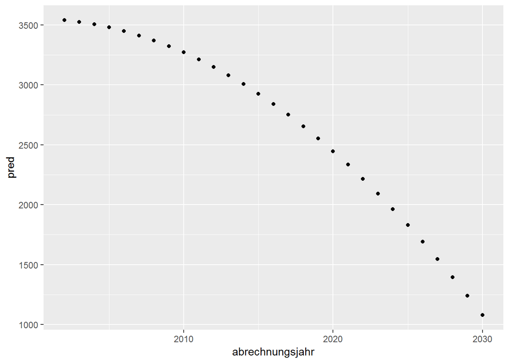

```r
quadmodel_mfh <- lm(total~abrechnungsjahr+I(abrechnungsjahr^2),data=berlin_co2_mfh)
from2002_till_2030 <- data.frame(abrechnungsjahr=2002:2030)
prognose_mfh <- data.frame(abrechnungsjahr = 2002:2030 , pred = as.numeric(predict(quadmodel_mfh,newdata=from2002_till_2030)))
ggplot(prognose_mfh , aes(x=abrechnungsjahr , y = pred))+geom_point()
```

Johannes used to use the index of the years, with 0 for 2002, 1 for 2003, and so on. I should do the same:

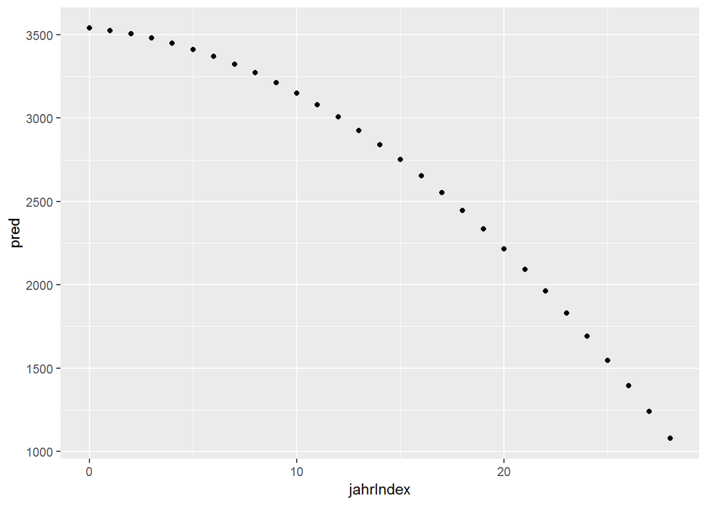

```r
berlin_co2_mfh_temp <- berlin_co2_mfh
berlin_co2_mfh_temp$jahrIndex <- berlin_co2_mfh_temp$abrechnungsjahr - 2002
quadmodel2_mfh <- lm(total~jahrIndex+I(jahrIndex^2),data=berlin_co2_mfh_temp)
from2002_till_2030_index <- data.frame(jahrIndex=(2002:2030) - 2002)
prognose2_mfh <- data.frame(jahrIndex = (2002:2030)-2002 , pred = as.numeric(predict(quadmodel2_mfh,newdata=from2002_till_2030_index)))
ggplot(prognose2_mfh , aes(x=jahrIndex , y = pred))+geom_point()
```

Apparently makes no difference…

```r
i_subsection <- i_subsection + 1
```

## 3.5. Diskussion

```r
i_section <- i_section + 1
i_subsection <- 1
```

# 4. Heizenergieverbrauch nach Stadtbezirken 2002 – 2018, alle Wohngebäude

## 4.1. Stadtbezirke, alle Wohngebäude, Heizenergieverbrauch 2002 - 2018 summiert

- `getAllBezirkeTotalCO2.R` and `getAllBezirkeByETCO2.R` both invoke `mainScriptCO2Emissions_v2.R`.
- `mainScriptCO2Emissions_v2.R` creates the attribute `energy_shares_absolute`. This is the energy produced by the respective ETs.
- So modify the returned object in `getAllBezirkeTotalCO2.R` and `getAllBezirkeByETCO2.R` so that it includes the `energy_shares_absolute` as well.
- Total energy split by ET:

```r
by_ten_9 <- 1e-9
aes_by_ET_TWh <- by_ten_9 * co2_allebezirke_byET$aes_all
aes_by_ET_TWh$abrechnungsjahr <- 2002:2018
aes_by_ET_TWh_cumsums <- getCumSums(obj=aes_by_ET_TWh , dropCols = c("abrechnungsjahr","total"))
```

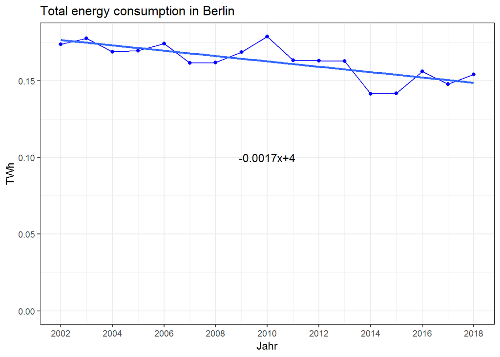

```r
points_line_lm(input_data = aes_by_ET_TWh,
               xVar = "abrechnungsjahr",
               yVar = "total",
               ymin = 0,
               ymax = max(aes_by_ET_TWh$total),
               x_eq = 2010,
               y_eq = 0.1,
               size_eq = 4,
               plot_title = "Total energy consumption in Berlin",
               xlab = "Jahr",
               ylab = "TWh",
               slope_round_to = 4)
```

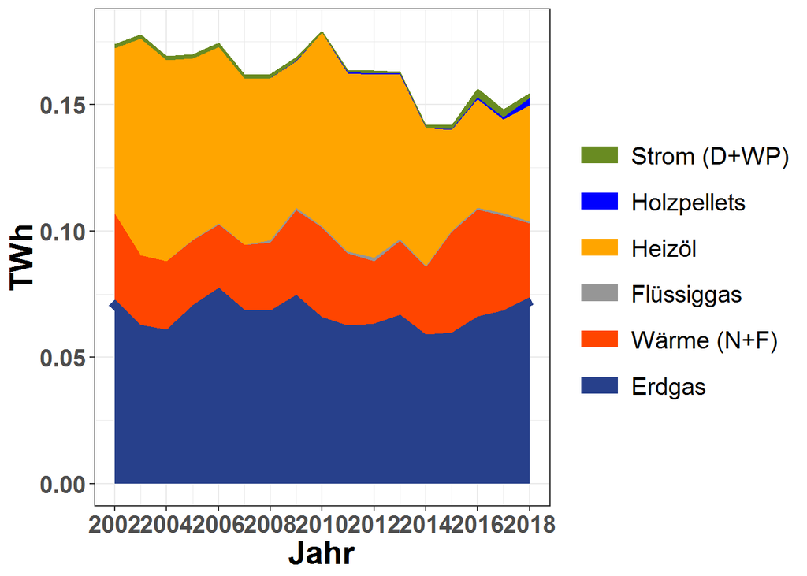

```r
plot_byET(aes_by_ET_TWh_cumsums , xlabel = "Jahr" , ylabel = "TWh" , plottitle = NULL)
```

- Total energy split by bezirk:

```r
by_ten_9 <- 1e-9
aes_by_bezirk_TWh <- by_ten_9 * alle_bezirke_co2$aes_all
aes_by_bezirk_TWh$abrechnungsjahr <- 2002:2018
aes_by_bezirk_TWh_cumsums <- getCumSums(obj=aes_by_bezirk_TWh , dropCols = "abrechnungsjahr")
```

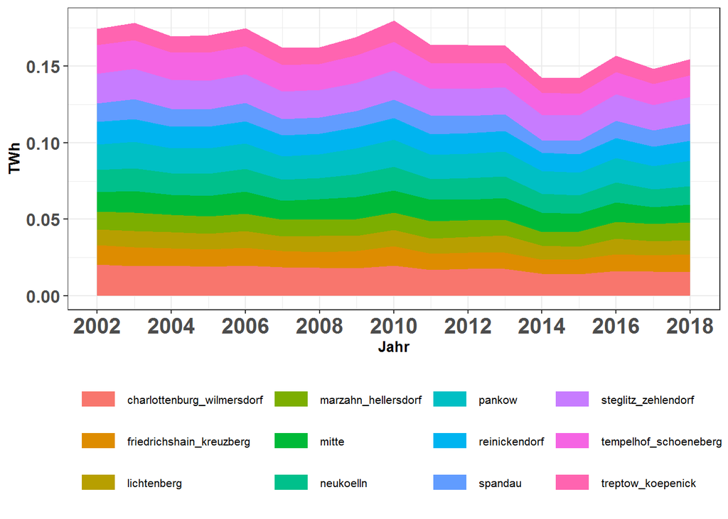

```r
plot_byBezirke(aes_by_bezirk_TWh_cumsums , xlabel = "Jahr" , ylabel = "TWh" , plottitle=NULL)
```

```r
i_subsection <- i_subsection+1
```

## 4.2. Stadtbezirke, alle Wohngebäude, flächenbezogener Heizenergieverbrauch 2002 – 2018 in kWh/(m2[AN]*a)

- `bezirk_areas_all$total` gives the total areas of berlin (MFH+SFH).
- `aes_by_ET_TWh$total` gives the total TWh consumption.
- So the quotient will give the per unit area consumption.

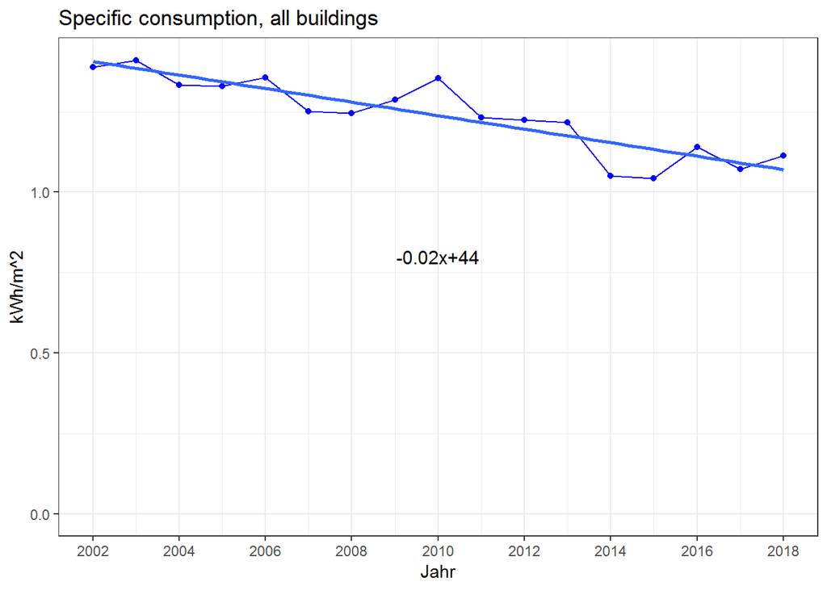

```r
spz_verbrauch_all <- data.frame(abrechnungsjahr=2002:2018,
                                kWh_per_m2 = 1e9 * aes_by_ET_TWh$total/bezirk_areas_all$total)
points_line_lm(input_data = spz_verbrauch_all,
               xVar = "abrechnungsjahr",
               yVar = "kWh_per_m2",
               ymin = 0,
               ymax = max(spz_verbrauch_all$kWh_per_m2),
               x_eq = 2010,
               y_eq = 0.8,
               size_eq = 4,
               plot_title = "Specific consumption, all buildings",
               xlab = "Jahr",
               ylab = "kWh/m^2")
```

```r
i_subsection <- i_subsection+1
```

## 4.3. Stadtbezirke, alle Wohngebäude, flächenbezogener Heizenergieverbrauch und beheizte Wohnfläche 2002 – 2018

Plot of the total area (to be combined with the specific energy consumption into one picture):

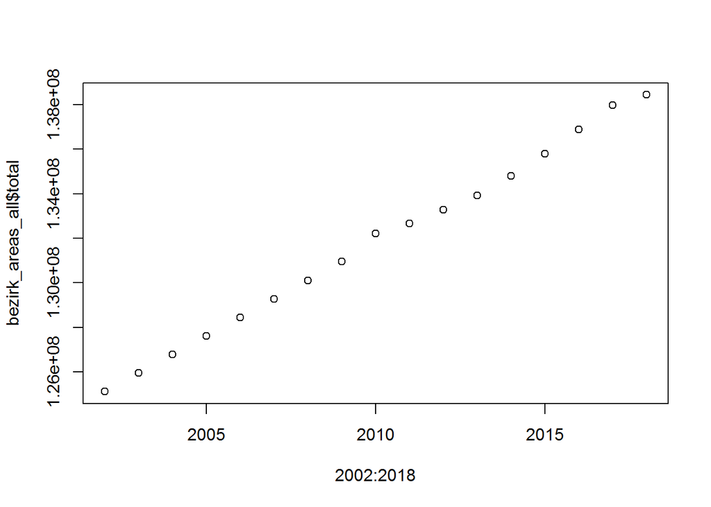

```r
plot(2002:2018 , bezirk_areas_all$total)
```

```r
i_section <- i_section + 1
i_subsection <- 1
```

# 5. Heizenergieverbrauch nach Stadtbezirken 2002 – 2018, 1-2 Familiengebäude

## 5.1. Stadtbezirke, 1-2 Familiengebäude, Heizenergieverbrauch 2002 - 2018 summiert

- Total energy split by ET:

```r
by_ten_9 <- 1e-9
aes_by_ET_TWh_sfh <- by_ten_9 * co2_allebezirke_byET$aes_sfh
aes_by_ET_TWh_sfh$abrechnungsjahr <- 2002:2018
aes_by_ET_TWh_sfh_cumsums <- getCumSums(obj=aes_by_ET_TWh_sfh , dropCols = c("abrechnungsjahr","total"))
```

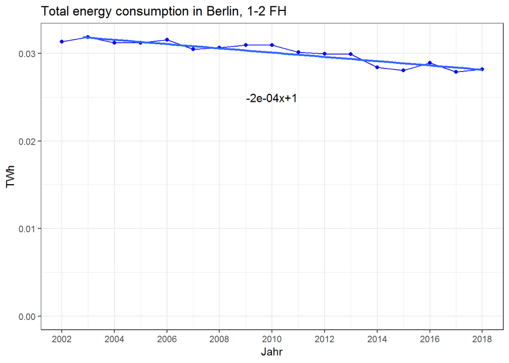

```r
points_line_lm(input_data = aes_by_ET_TWh_sfh,
               xVar = "abrechnungsjahr",
               yVar = "total",
               ymin = 0,
               ymax = max(aes_by_ET_TWh_sfh$total),
               x_eq = 2010,
               y_eq = 0.025,
               size_eq = 4,
               plot_title = "Total energy consumption in Berlin, 1-2 FH",
               xlab = "Jahr",
               ylab = "TWh",
               slope_round_to = 4)
```

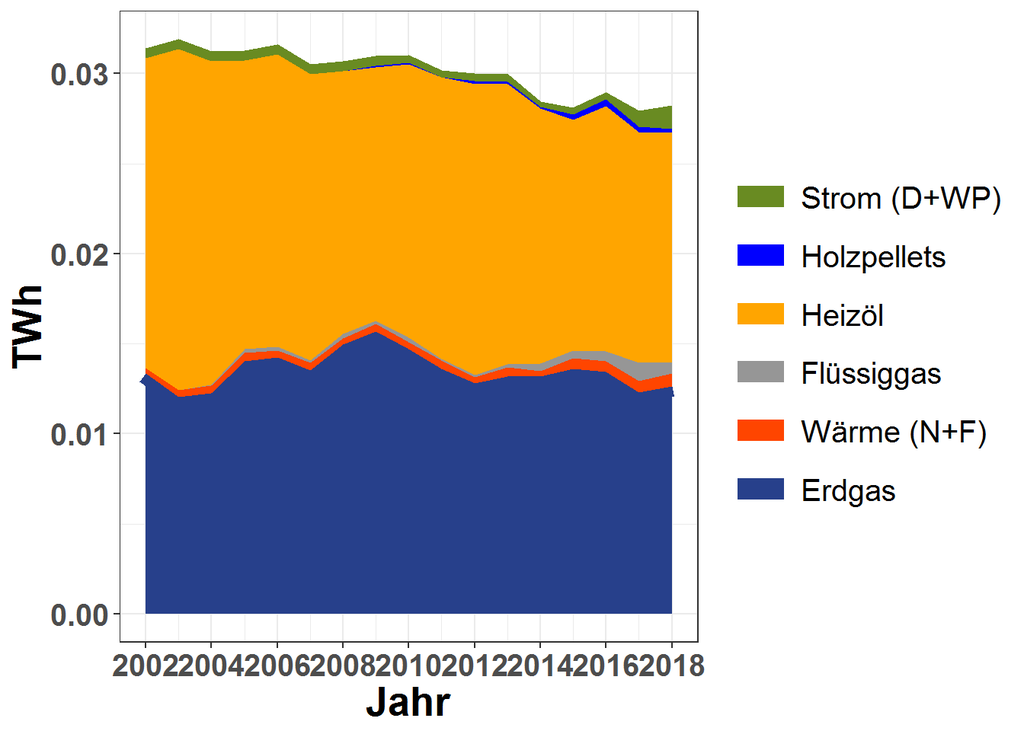

```r
plot_byET(aes_by_ET_TWh_sfh_cumsums , xlabel = "Jahr" , ylabel = "TWh" , plottitle = NULL)
```

- Total energy split by bezirk:

```r
by_ten_9 <- 1e-9
aes_by_bezirk_TWh_sfh <- by_ten_9 * alle_bezirke_co2$aes_sfh
aes_by_bezirk_TWh_sfh$abrechnungsjahr <- 2002:2018
aes_by_bezirk_TWh_sfh_cumsums <- getCumSums(obj=aes_by_bezirk_TWh_sfh , dropCols = "abrechnungsjahr")
```

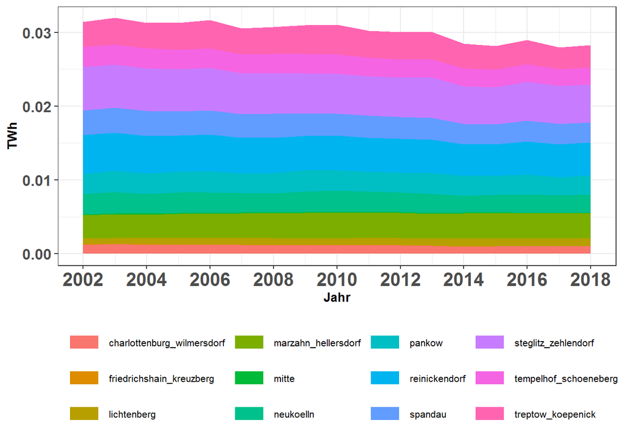

```r
plot_byBezirke(aes_by_bezirk_TWh_sfh_cumsums , xlabel = "Jahr" , ylabel = "TWh" , plottitle=NULL)
```

```r
i_subsection <- i_subsection+1
```

## 5.2. Stadtbezirke, 1-2 Familiengebäude, flächenbezogener Heizenergieverbrauch 2002 – 2018 in kWh/(m2[AN]*a)

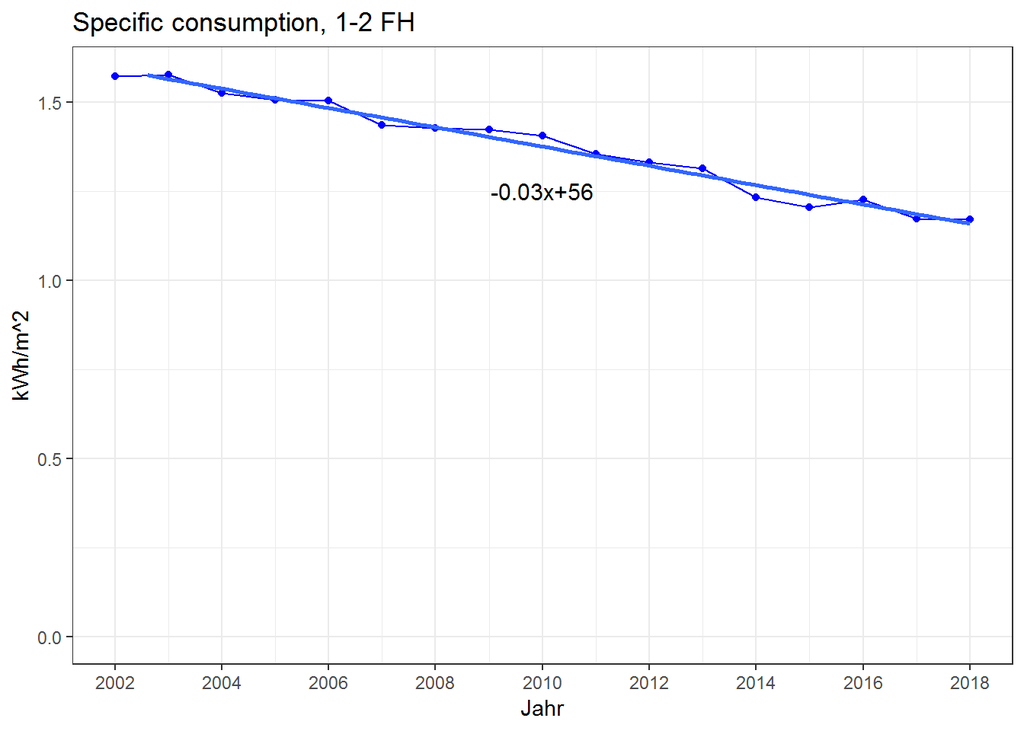

```r
spz_verbrauch_sfh <- data.frame(abrechnungsjahr=2002:2018,
                                kWh_per_m2 = 1e9 * aes_by_ET_TWh_sfh$total/bezirk_areas_sfh$total)
points_line_lm(input_data = spz_verbrauch_sfh,
               xVar = "abrechnungsjahr",
               yVar = "kWh_per_m2",
               ymin = 0,
               ymax = max(spz_verbrauch_sfh$kWh_per_m2),
               x_eq = 2010,
               y_eq = 1.25,
               size_eq = 4,
               plot_title = "Specific consumption, 1-2 FH",
               xlab = "Jahr",
               ylab = "kWh/m^2")
```

```r
i_subsection <- i_subsection+1
```

## 5.3. Stadtbezirke, 1-2 Familiengebäude, flächenbezogener Heizenergieverbrauch und beheizte Wohnfläche 2002 – 2018

Plot of the 1-2 FH area (to be combined with the specific energy consumption into one picture):

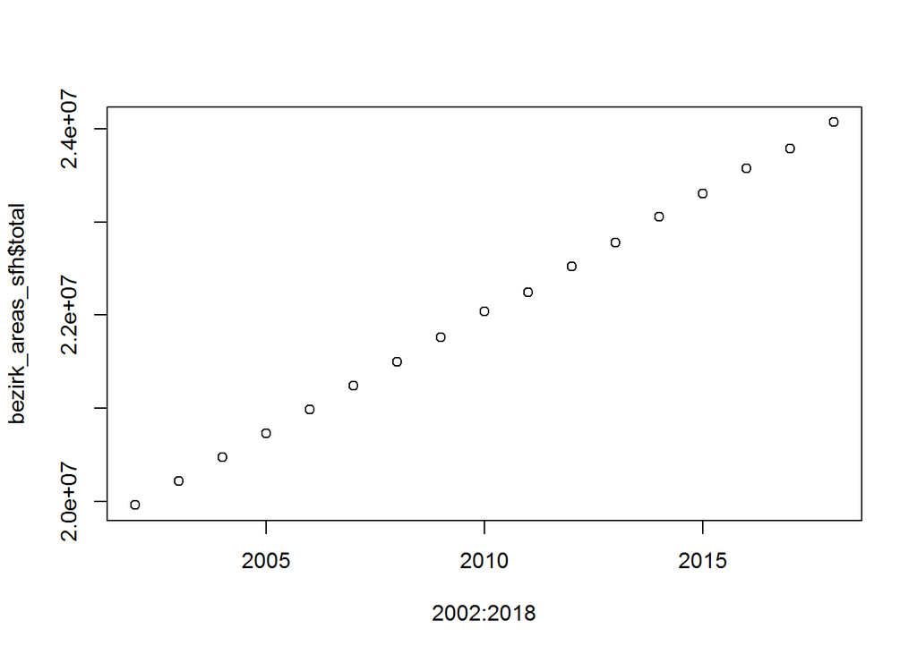

```r
plot(2002:2018 , bezirk_areas_sfh$total)
```

```r
i_section <- i_section + 1
i_subsection <- 1
```

# 6. Heizenergieverbrauch nach Stadtbezirken 2002 – 2018, Mehrfamiliengebäude

## 6.1. Stadtbezirke, Mehrfamiliengebäude, Heizenergieverbrauch 2002 - 2018 summiert

- Total energy split by ET:

```r
by_ten_9 <- 1e-9
aes_by_ET_TWh_mfh <- by_ten_9 * co2_allebezirke_byET$aes_mfh
aes_by_ET_TWh_mfh$abrechnungsjahr <- 2002:2018
aes_by_ET_TWh_mfh_cumsums <- getCumSums(obj=aes_by_ET_TWh_mfh , dropCols = c("abrechnungsjahr","total"))
```

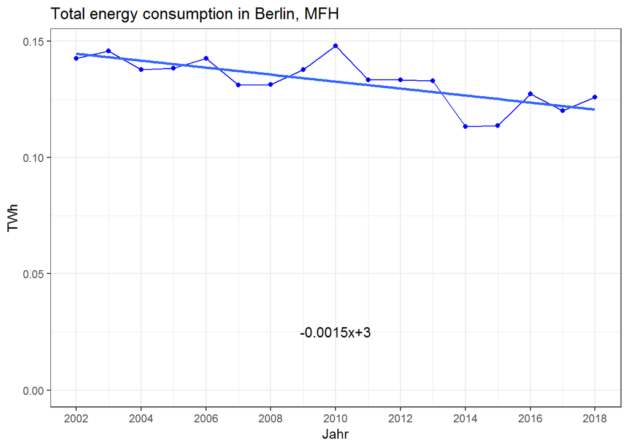

```r
points_line_lm(input_data = aes_by_ET_TWh_mfh,
               xVar = "abrechnungsjahr",
               yVar = "total",
               ymin = 0,
               ymax = max(aes_by_ET_TWh_mfh$total),
               x_eq = 2010,
               y_eq = 0.025,
               size_eq = 4,
               plot_title = "Total energy consumption in Berlin, MFH",
               xlab = "Jahr",
               ylab = "TWh",
               slope_round_to = 4)
```

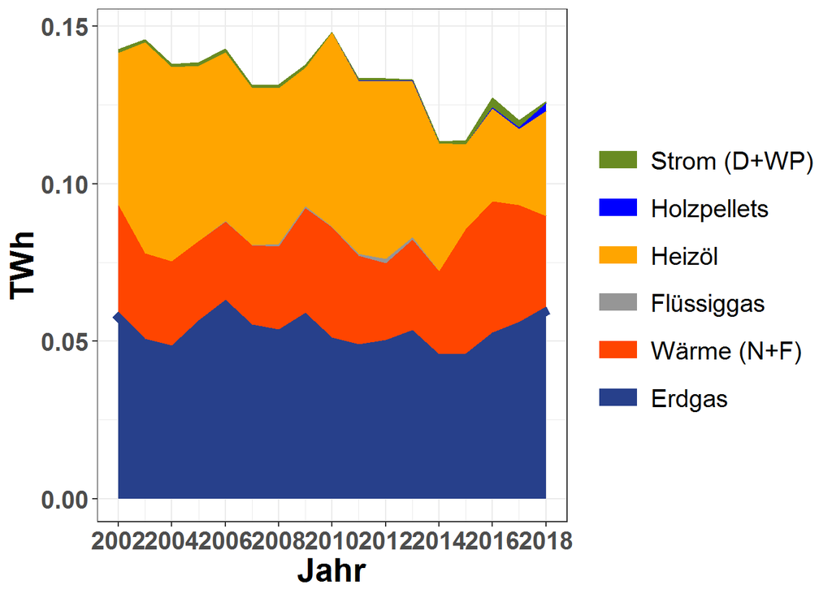

```r
plot_byET(aes_by_ET_TWh_mfh_cumsums , xlabel = "Jahr" , ylabel = "TWh" , plottitle = NULL)
```

- Total energy split by bezirk:

```r
by_ten_9 <- 1e-9
aes_by_bezirk_TWh_mfh <- by_ten_9 * alle_bezirke_co2$aes_mfh
aes_by_bezirk_TWh_mfh$abrechnungsjahr <- 2002:2018
aes_by_bezirk_TWh_mfh_cumsums <- getCumSums(obj=aes_by_bezirk_TWh_mfh , dropCols = "abrechnungsjahr")
```

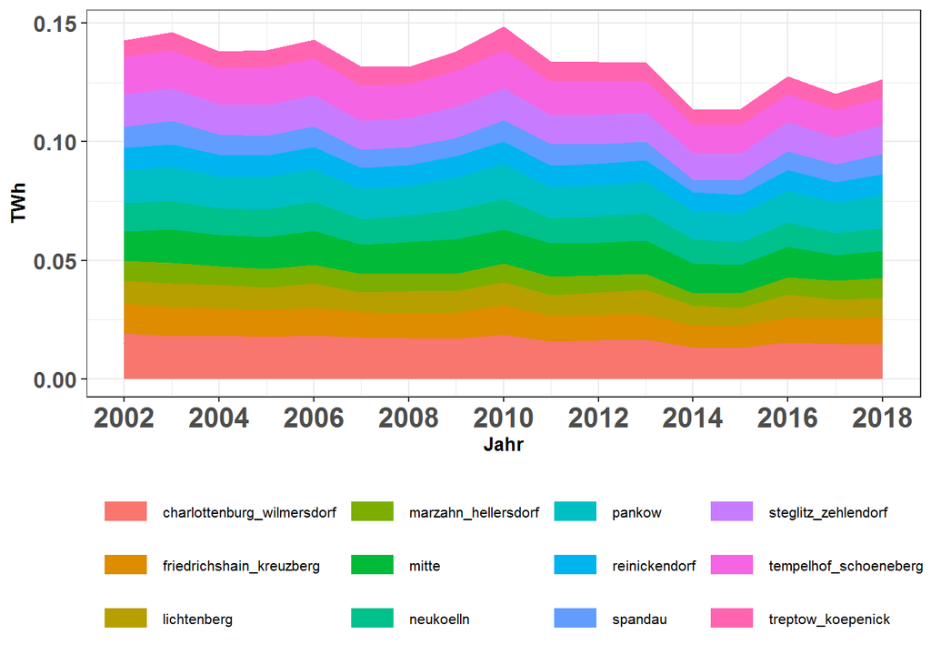

```r
plot_byBezirke(aes_by_bezirk_TWh_mfh_cumsums , xlabel = "Jahr" , ylabel = "TWh" , plottitle=NULL)
```

```r
i_subsection <- i_subsection+1
```

## 6.2. Stadtbezirke, Mehrfamiliengebäude, flächenbezogener Heizenergieverbrauch 2002 – 2018 in kWh/(m2[AN]*a)

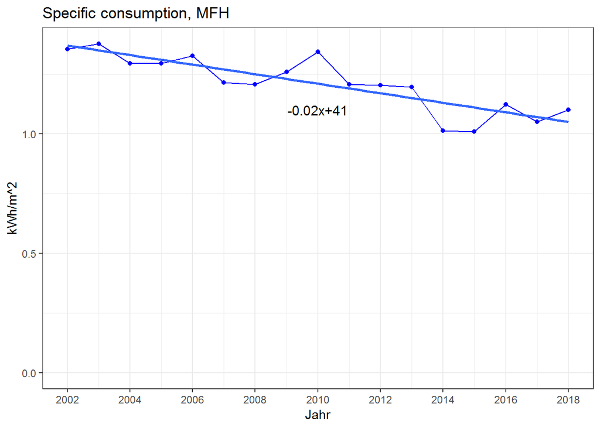

```r
spz_verbrauch_mfh <- data.frame(abrechnungsjahr=2002:2018,
                                kWh_per_m2 = 1e9 * aes_by_ET_TWh_mfh$total/bezirk_areas_mfh$total)
points_line_lm(input_data = spz_verbrauch_mfh,
               xVar = "abrechnungsjahr",
               yVar = "kWh_per_m2",
               ymin = 0,
               ymax = max(spz_verbrauch_mfh$kWh_per_m2),
               x_eq = 2010,
               y_eq = 1.1,
               size_eq = 4,
               plot_title = "Specific consumption, MFH",
               xlab = "Jahr",
               ylab = "kWh/m^2")
```

```r
i_subsection <- i_subsection+1
```

## 6.3. Stadtbezirke, Mehrfamiliengebäude, flächenbezogener Heizenergieverbrauch und beheizte Wohnfläche 2002 – 2018

Plot of the MFH area (to be combined with the specific energy consumption into one picture):

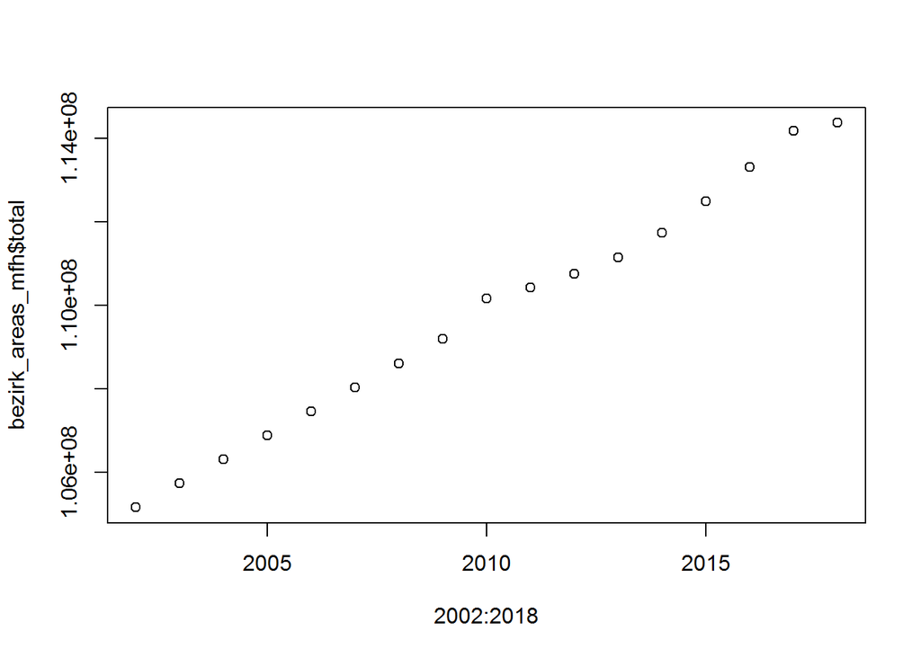

```r
plot(2002:2018 , bezirk_areas_mfh$total)
```